# Analyzing Phrases with tidytext

As always, we set the working directory and then load the packages we want.

```r
library(tidyverse)
library(tidytext)
library(okcupiddata)
library(scales) # scale functions for visualization
library(igraph)
library(ggraph)
```

We continue the analysis of the OKCupid essays, and just to add some further interests we compare responses of smokers and non-smokers.

For clarity, let’s break the process down into steps. First, subset the okcupid `profiles` to include just the essay responses and the user’s response about smoking. The `data_frame` function creates a tibble. In creating the tibble, we rename `essay0` as `text` – not necessary, but follows the example in Silge and Robinson.

Then we create a new binary variable, `smoker` that identifies non-smokers as “no” and everyone else as “yes”, dropping the original `smokes` variable (notice the command `select(-smokes)`, which selects all columns *except for* `smokes`.

```r
tidy_okcupid <- select_(profiles,"essay0","smokes")
tidy_okcupid <- data_frame(smokes=profiles$smokes,text=profiles$essay0)
tidy_okcupid <- tidy_okcupid %>%
     mutate(smoker = ifelse(smokes=="no","no","yes")) %>%
     select(-smokes)
```

```r
tidy_smoker <- tidy_okcupid %>%
     select(smoker, text) %>%
     na.omit()
smoker_bigrams <- unnest_tokens(tidy_smoker, bigram, text, token="ngrams", n=2)
smoker_bigrams
```

| smoker | bigram |
| --- | --- |
| no | i am |
| no | am a |
| no | a chef |
| no | chef this |
| no | this is |
| no | is what |
| no | what that |
| no | that means |
| no | means 1 |
| no | 1 i |

[output cut: 990 more lines]

At this point, the tibble `smoker_bigrams` consists of more than 1,226,000 pairs of adjacent words. The next code chunk counts and sorts the pairs to find the most common ones. After that, it `separate`s the pairs into `word1` and `word2` to search for and remove stopwords, and then `unite`s the pairs that remain, finally recounting and sorting the shorter list of pairs.

Consult Silge & Robinson to learn how to customize the list of stopwords.

```r
smoker_bigrams %>%
     count(bigram, sort = TRUE)
```

| bigram | n |
| --- | --- |
| i am | 14243 |
| i'm a | 6571 |
| i love | 6445 |
| in the | 5275 |
| i like | 4480 |
| i have | 4346 |
| am a | 4215 |
| and i | 3382 |
| san francisco | 3269 |
| like to | 3128 |

[output cut: 990 more lines]

```r
bigrams_separated <- smoker_bigrams %>%
     separate(bigram, c("word1", "word2"), sep = " ")

bigrams_filtered <- bigrams_separated %>%
     filter(!word1 %in% stop_words$word) %>%
     filter(!word2 %in% stop_words$word)

# new bigram counts:
bigram_counts <- bigrams_filtered %>%
     count(word1, word2, smoker, sort = TRUE)

bigram_counts
```

| word1 | word2 | smoker | n |
| --- | --- | --- | --- |
| san | francisco | no | 2669 |
| east | coast | no | 750 |
| san | francisco | yes | 600 |
| fun | loving | no | 537 |
| recently | moved | no | 449 |
| east | bay | no | 254 |
| online | dating | no | 229 |
| enjoy | life | no | 214 |
| grad | school | no | 208 |
| san | diego | no | 187 |

[output cut: 990 more lines]

```r
bigrams_united <- bigrams_filtered %>%
     unite(bigram, word1, word2, sep = " ")

bigrams_united
```

| smoker | bigram |
| --- | --- |
| no | means 1 |
| no | workaholic 2 |
| no | writing public |
| no | public text |
| no | online dating |
| no | dating site |
| no | site makes |
| no | pleasantly uncomfortable |
| no | school hey |
| no | australian living |

[output cut: 990 more lines]

As noted in class and in the readings, a simple frequency count can be misleading. The next code chunk weights term frequency by the inverse frequency within the documents (smokers vs non-smokers.

```r
     bigram_tf_idf <- bigrams_united %>%
          count(smoker, bigram) %>%
          bind_tf_idf(bigram, smoker, n) %>%
          arrange(desc(tf_idf))

     bigram_tf_idf
```

| smoker | bigram | n | tf | idf | tf_idf |
| --- | --- | --- | --- | --- | --- |
| yes | words 500 | 13 | 4.362270e-04 | 0.6931472 | 3.023695e-04 |
| yes | uh uh | 7 | 2.348914e-04 | 0.6931472 | 1.628143e-04 |
| yes | smoke cigarettes | 6 | 2.013355e-04 | 0.6931472 | 1.395552e-04 |
| no | playing tennis | 25 | 1.924661e-04 | 0.6931472 | 1.334073e-04 |
| no | running hiking | 24 | 1.847675e-04 | 0.6931472 | 1.280710e-04 |
| no | bike riding | 23 | 1.770688e-04 | 0.6931472 | 1.227348e-04 |
| no | meow meow | 22 | 1.693702e-04 | 0.6931472 | 1.173985e-04 |
| no | intellectually curious | 20 | 1.539729e-04 | 0.6931472 | 1.067259e-04 |
| no | mountain view | 19 | 1.462742e-04 | 0.6931472 | 1.013896e-04 |
| no | school teacher | 19 | 1.462742e-04 | 0.6931472 | 1.013896e-04 |

[output cut: 990 more lines]

```r
     bigrams_separated %>%
          filter(word1 == "not") %>%
          count(word1, word2, sort = TRUE)
```

| word1 | word2 | n |
| --- | --- | --- |
| not | a | 365 |
| not | to | 227 |
| not | really | 213 |
| not | sure | 196 |
| not | looking | 165 |
| not | the | 146 |
| not | so | 111 |
| not | in | 97 |
| not | very | 96 |
| not | too | 84 |

[output cut: 985 more lines]

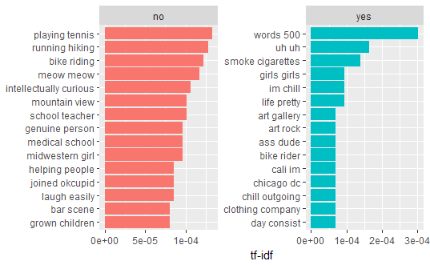

```r
plot_pairs <- bigram_tf_idf %>%
  arrange(desc(tf_idf)) %>%
  mutate(pair = factor(bigram, levels = rev(unique(bigram))))
plot_pairs %>%
  group_by(smoker) %>%
  top_n(15) %>%
  ungroup %>%
  ggplot(aes(pair, tf_idf, fill = smoker)) +
  geom_col(show.legend = FALSE) +
  labs(x = NULL, y = "tf-idf") +
  facet_wrap(~smoker, ncol = 2, scales = "free") +
  coord_flip()
```

# Sentiment Analysis

DataCamp introduced you to Sentiment Analysis. This next chunk follows the Silge & Robinson example. We specifically look for word pairs beginning that include negation (like “not”), since that can be a common style.

```r
     AFINN <- get_sentiments("afinn")

     not_words <- bigrams_separated %>%
          filter(word1 == "not") %>%
          inner_join(AFINN, by = c(word2 = "word")) %>%
          count(word2, score, sort = TRUE) %>%
          ungroup()

     not_words
```

| word2 | score | n |
| --- | --- | --- |
| good | 3 | 70 |
| afraid | -2 | 63 |
| like | 2 | 45 |
| interested | 2 | 42 |
| easy | 1 | 23 |
| shy | -1 | 23 |
| great | 3 | 22 |
| perfect | 3 | 17 |
| want | 1 | 13 |
| crazy | -2 | 9 |

[output cut: 158 more lines]

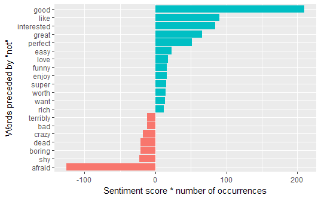

```r
     not_words %>%
          mutate(contribution = n * score) %>%
          arrange(desc(abs(contribution))) %>%
          head(20) %>%
          mutate(word2 = reorder(word2, contribution)) %>%
          ggplot(aes(word2, n * score, fill = n * score > 0)) +
          geom_col(show.legend = FALSE) +
          xlab("Words preceded by \"not\"") +
          ylab("Sentiment score * number of occurrences") +
          coord_flip()
```

```r
     negation_words <- c("not", "no", "never", "without")

     negated_words <- bigrams_separated %>%
          filter(word1 %in% negation_words) %>%
          inner_join(AFINN, by = c(word2 = "word")) %>%
          count(word1, word2, score, sort = TRUE) %>%
          ungroup()
```

```r
     # original counts
     bigram_counts
```

| word1 | word2 | smoker | n |
| --- | --- | --- | --- |
| san | francisco | no | 2669 |
| east | coast | no | 750 |
| san | francisco | yes | 600 |
| fun | loving | no | 537 |
| recently | moved | no | 449 |
| east | bay | no | 254 |
| online | dating | no | 229 |
| enjoy | life | no | 214 |
| grad | school | no | 208 |
| san | diego | no | 187 |

[output cut: 990 more lines]

```r
# filter for only relatively common combinations
# might want to experiment with values other than 20 in filter line
     bigram_graph <- bigram_counts %>%
          group_by(smoker) %>%
          filter(n > 20) %>%
          filter(smoker=="yes") %>%
          graph_from_data_frame()

     bigram_graph
```

```
IGRAPH 62f46dc DN-- 49 33 --
+ attr: name (v/c), smoker (e/c), n (e/n)
+ edges from 62f46dc (vertex names):
 [1] san     ->francisco  recently->moved
 [3] fun     ->loving     east    ->coast
 [5] love    ->music      east    ->bay
 [7] online  ->dating     san     ->diego
 [9] months  ->ago        blah    ->blah
[11] people  ->laugh      pretty  ->laid
[13] meet    ->people     nice    ->guy
[15] pretty  ->easy       video   ->games
+ ... omitted several edges
```

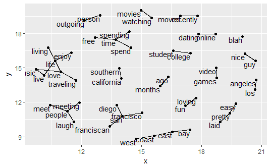

```r
     set.seed(2018)

     ggraph(bigram_graph, layout = "fr") +
          geom_edge_link() +
          geom_node_point() +
          geom_node_text(aes(label = name),  vjust = 1, hjust = 1)
```

Finally, as in Chapter 4 of Silge and Robinson (which was not assigned), here’s an alternative and more attractive network graph. This will use the same subset of participants as the one created above.

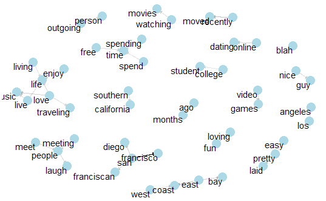

```r
     set.seed(2018)

     a <- grid::arrow(type = "closed", length = unit(.05, "inches"))

     ggraph(bigram_graph, layout = "fr") +
          geom_edge_link(aes(edge_alpha = n), show.legend = FALSE,
                         arrow = a, end_cap = circle(.05, 'inches')) +
          geom_node_point(color = "lightblue", size = 5) +
          geom_node_text(aes(label = name), vjust = 1, hjust = 1) +
          theme_void()
```

```r
NA
```